# Part 3: Statistical modelling

08 August, 2019

## Statistical Modelling in R

## Notes

order of included R functions:

- `lm()`
- `summary()`
- `ggplot() + statqq()`
- `ggplot() + geom_smooth()`
- `tidy(), augment(), glance()`
- `summ(), plot_summs()`
- `autoplot()`
- `glm() (different families), coef(), exp()`
- `lmer()`

## What we cover

- Model results presentation
- Model Diagnostics
- Tidy Tables and Graphs

**For:**

- Linear Regression
- Multiple Linear Regression
- Generalized Linear Models
- Briefly: Mixed effects model

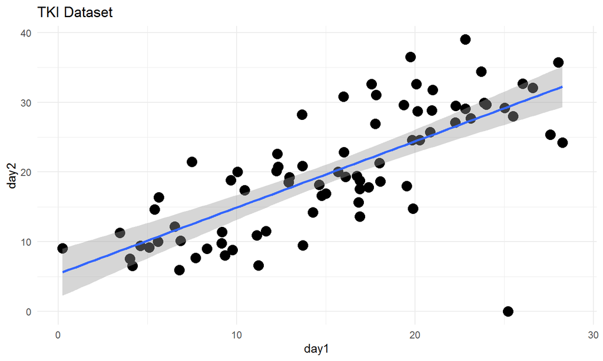

## Linear Regression

## Linear Regression in R

In a linear regression, we aim to find a model:

- that represents our data and
- can give information about the association between our variables of interest. The command in R for a linear model is

`lm(y ~ x, data = data)`.

This is called the *formula notation* in R.

## ! Tip in the tidyverse

- The formula-type code with the data assignment at the end might seem non-tidy.
- But, we can use the pipe `%>%` in the following way:

```r
data %>%
      lm(y ~ x, data = .)
```

- with the “.” we assign the data in the pipe

## Before we model

## Data set summary

Let’s first have a look at the summary table of the example data set, by using the `summary()` command:

```r
summary(tki_demo[,c(6:8)])
```

```
##       day1             day2               day3
##  Min.   :-1.611   Min.   :  0.2396   Min.   : 0.00
##  1st Qu.: 3.031   1st Qu.:  9.9763   1st Qu.:13.25
##  Median : 5.619   Median : 15.9973   Median :19.37
##  Mean   : 5.428   Mean   : 16.7252   Mean   :20.27
##  3rd Qu.: 7.772   3rd Qu.: 20.6984   3rd Qu.:28.05
##  Max.   :12.142   Max.   :143.8187   Max.   :39.03
##                   NA's   :4          NA's   :16
```

## Visualisation of data distributions

## Helpful plots before modelling

Before we start with the linear regression model, we need to get an idea of the underlying data and its distribution. We know that the linear regression has the assumtptions:

- Linear relationship
- Multivariate normality
- No or little multicollinearity
- No auto-correlation
- Homoscedasticity

## QQ-plot:

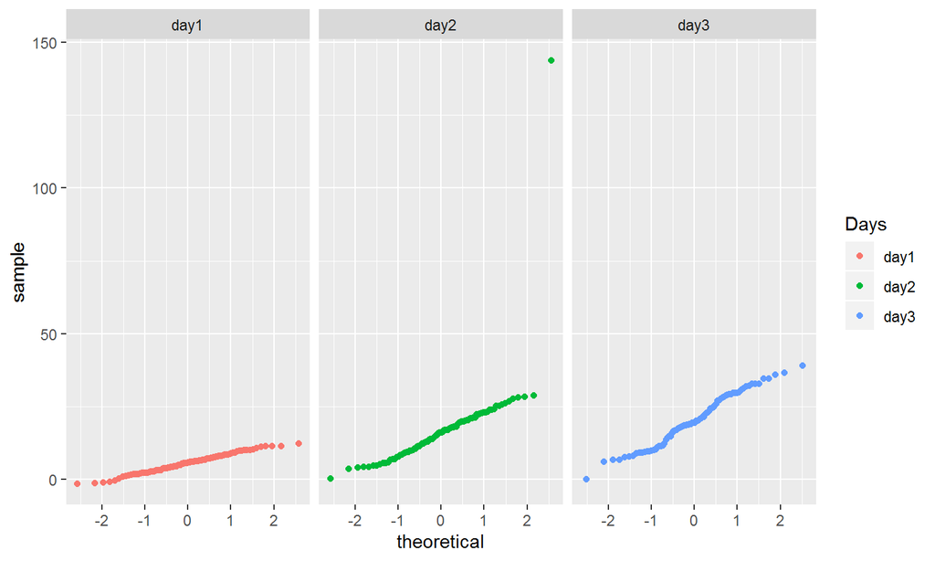

```r
tki_demo %>%
  gather(Days, measurement, day1:day3, factor_key = TRUE) %>%
  ggplot( aes(sample = measurement, color=Days)) + stat_qq() + facet_wrap(~Days)
```

## Boxplots to check for outliers

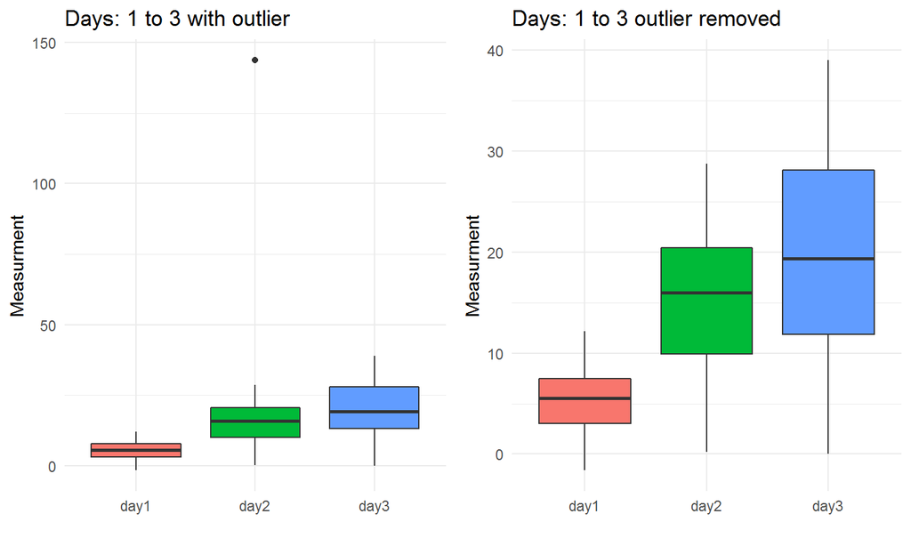

## Plot the variables

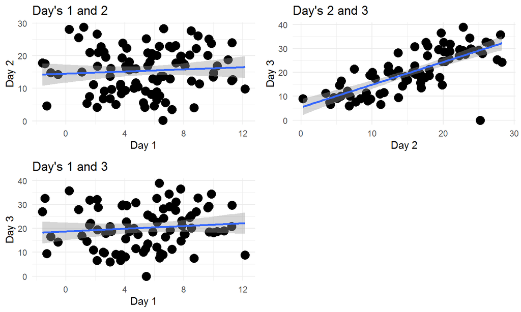

## Linear Regression

## The `lm()` function

In the plots, we could already see, that *day 2* and *day 3* seem to be associated. This is obvious when drawing a line in the plot. Let’s now perform a linear regression model in R.

`lm(day3 ~ day2, data = tki_demo)`

- As said before, the first argument in the code is *y*, our outcome variable or *dependent variable*. In this case it is *day3*.
- The second Argument is *x*, the *independent variable*. In our case: *day2*.
- We also specify the data set that holds the variables we specified as *x* and *y*.

## Linear Regression Results

Now we want to look at the results of the linear regression. So how do we get the *p-value* and *\(\beta\)-coefficient* for the association?

In R, we add the `summary()` function to the `lm()` function, like so:

`summary(lm(y ~ x, data = data))`

We can also store our model results in a variable:  
`model1 <- lm(y ~ x, data = data)`, and then use summary: `summary(model1)`

## Example Results

```
##
## Call:
## lm(formula = day3 ~ day1, data = tki_demo)
##
## Residuals:
##      Min       1Q   Median       3Q      Max
## -20.3114  -7.1324  -0.9278   7.6063  18.4620
##
## Coefficients:
##             Estimate Std. Error t value Pr(>|t|)
## (Intercept)  18.7585     1.8596  10.087 5.02e-16 ***
## day1          0.2855     0.3003   0.951    0.345
## ---
## Signif. codes:  0 '***' 0.001 '**' 0.01 '*' 0.05 '.' 0.1 ' ' 1
##
## Residual standard error: 8.82 on 82 degrees of freedom
##   (16 observations deleted due to missingness)
## Multiple R-squared:  0.0109, Adjusted R-squared:  -0.001158
## F-statistic: 0.904 on 1 and 82 DF,  p-value: 0.3445
```

## `jtools` and `broom`

## Improving the accessibility of the `lm()` results

- The output before contains a lot of relevant information, but it is not straighforward to access the individual parameters like p-values and betas.
- The `broom` R package is in line with the “tidy” data handling in R and turns the linear model results into an easy accessible tibble format:

```r
tidy(lm1)
```

```
## # A tibble: 2 x 5
##   term        estimate std.error statistic  p.value
##   <chr>          <dbl>     <dbl>     <dbl>    <dbl>
## 1 (Intercept)   18.8       1.86     10.1   5.02e-16
## 2 day1           0.286     0.300     0.951 3.45e- 1
```

## Improving output style

- The `broom` package helps with the accessibility of the output, but the style of the output is not very appealing for a publiation or a report.
- The `jtools` package helps with this and has other nice functionalities such as forrest plots for coefficients and confidence intervals:

```r
export_summs(lm1)
```

|  | Model 1 |
| --- | --- |
| (Intercept) | 18.76 *** |
|  | (1.86) |
| day1 | 0.29 |
|  | (0.30) |
| N | 84 |
| R2 | 0.01 |
| *** p < 0.001; ** p < 0.01; * p < 0.05. |  |

## Access more model info for diagnostics: `broom`

```r
model <- lm(day3 ~ day2, data = tki_demo)
head(augment(model))
```

| .rownames | day3 | day2 | .fitted | .se.fit | .resid | .hat | .sigma | .cooksd | .std.resid |
| --- | --- | --- | --- | --- | --- | --- | --- | --- | --- |
| 1 | 29.6 | 19.4 | 20.4 | 0.965 | 9.2 | 0.0128 | 8.53 | 0.00761 | 1.08 |
| 3 | 39 | 22.8 | 21 | 1.02 | 18 | 0.0142 | 8.34 | 0.0325 | 2.13 |
| 4 | 9.41 | 4.61 | 18 | 1.22 | -8.6 | 0.0203 | 8.54 | 0.0107 | -1.02 |
| 5 | 14.7 | 19.9 | 20.5 | 0.97 | -5.78 | 0.0129 | 8.57 | 0.00303 | -0.681 |
| 7 | 24.6 | 20.3 | 20.6 | 0.975 | 4.03 | 0.013 | 8.58 | 0.00149 | 0.475 |
| 9 | 9.47 | 13.7 | 19.5 | 0.976 | -10 | 0.0131 | 8.52 | 0.00924 | -1.18 |

## Diagnostic Plots

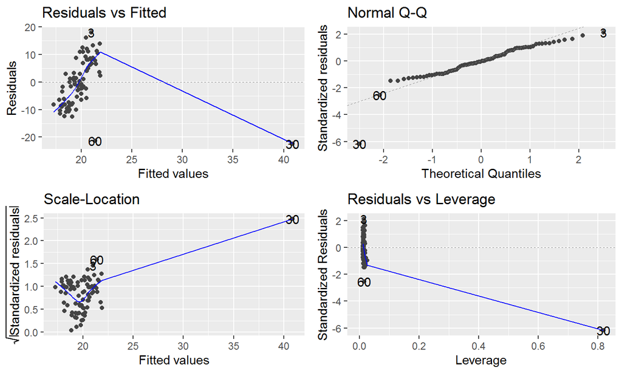

```r
autoplot(model)
```

## Multiple Linear Regression

## Multiple Linear Regression in R

Multiple linear regression works with the same function in R :  
`lm(y ~ x + covar1 + covar2 + … + covarx , data = data)`

```r
export_summs(lm(day3 ~ day2 + male, data = tki_demo))
```

|  | Model 1 |
| --- | --- |
| (Intercept) | 15.24 *** |
|  | (1.44) |
| day2 | 0.15 * |
|  | (0.06) |
| maleTRUE | 6.47 *** |
|  | (1.88) |
| N | 80 |
| R2 | 0.21 |
| *** p < 0.001; ** p < 0.01; * p < 0.05. |  |

## Example 1: one model

With the demo data set:

```r
export_summs(lm(day3 ~ day2 + male + smoker, data = tki_demo))
```

|  | Model 1 |
| --- | --- |
| (Intercept) | 15.81 *** |
|  | (1.46) |
| day2 | 0.16 ** |
|  | (0.06) |
| maleTRUE | 7.11 *** |
|  | (1.89) |
| smokerTRUE | -3.67 |
|  | (2.03) |
| N | 80 |
| R2 | 0.24 |
| *** p < 0.001; ** p < 0.01; * p < 0.05. |  |

## Example 2: more models

With the demo data set:

```r
lm1 <- lm(day3 ~ day2 + male, data = tki_demo)
lm2 <- lm(day3 ~ day2 + male + smoker, data = tki_demo)
export_summs(lm1, lm2)
```

|  | Model 1 | Model 2 |
| --- | --- | --- |
| (Intercept) | 15.24 *** | 15.81 *** |
|  | (1.44) | (1.46) |
| day2 | 0.15 * | 0.16 ** |
|  | (0.06) | (0.06) |
| maleTRUE | 6.47 *** | 7.11 *** |
|  | (1.88) | (1.89) |
| smokerTRUE |  | -3.67 |
|  |  | (2.03) |
| N | 80 | 80 |
| R2 | 0.21 | 0.24 |
| *** p < 0.001; ** p < 0.01; * p < 0.05. |  |  |

## Forrest plot to compare coefficients in the model

- Often we want to visualise the coefficients in the model to see their impact on the outcome, or visualise the coefficient of specific variable in two models, that differ only in the adjusted covariates.
- The `jtools` package has a nice function to do this very easily, utilising `ggplot2`:  
  `plot_summs()`

## Example 1: one model

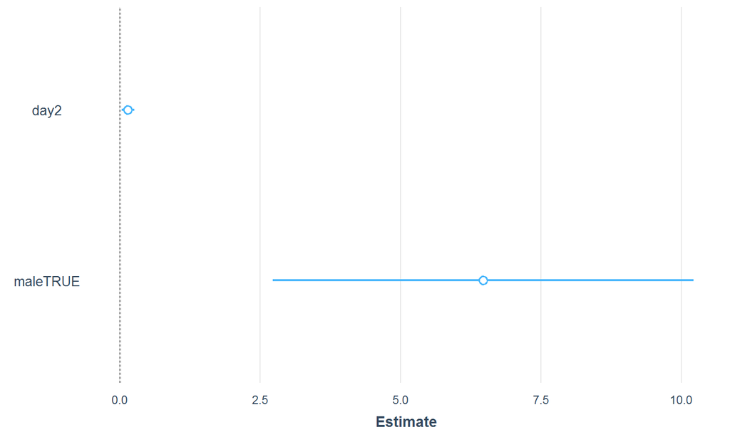

```r
plot_summs(lm1)
```

## Example 2: more models

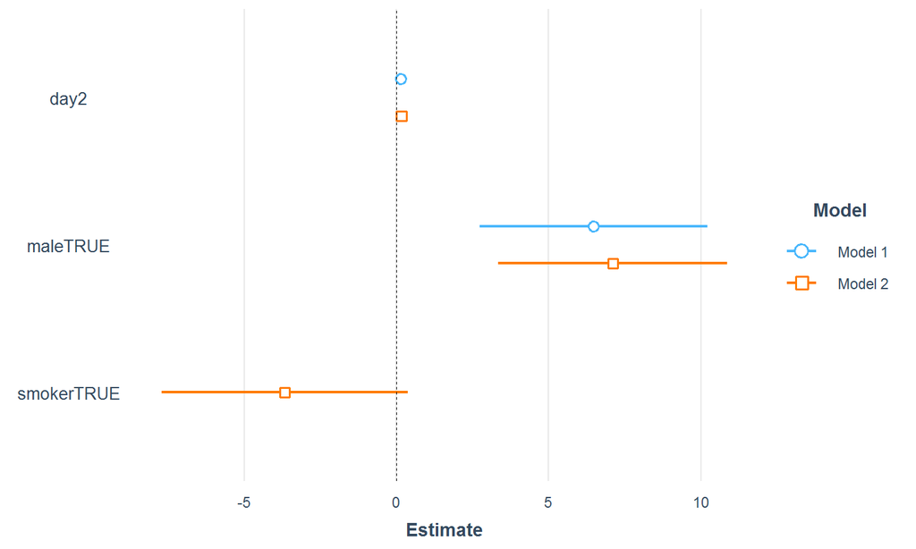

```r
plot_summs(lm1, lm2)
```

## Example 3: compare specific coefficients

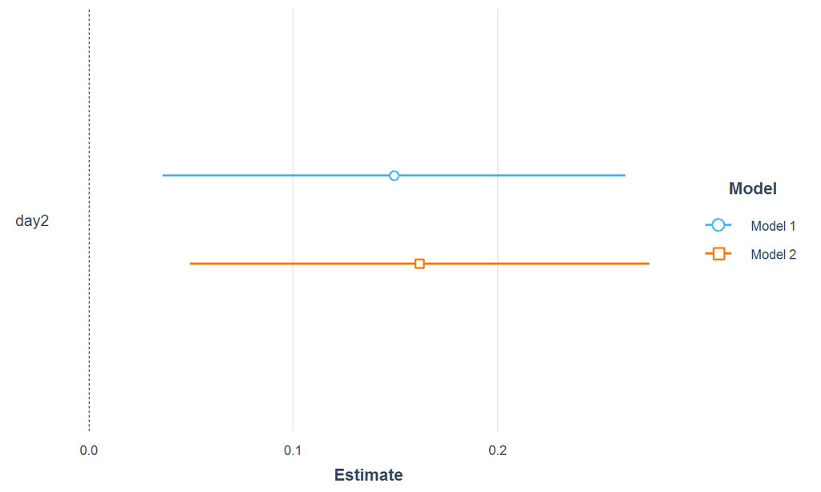

```r
plot_summs(lm1, lm2, coefs = "day2")
```

## Getting more info: Confidence Intervalls

- With `jtools` we can access more information from the model in an easy step.
- Here, we access the confidence intervall and variance inflation factor (for multicollinearity testing), but leave out the p-values:

```r
summ(lm2, scale = TRUE, vifs = TRUE, part.corr = TRUE,
     confint = TRUE, pvals = FALSE)$coeftable
```

```
##                  Est.       2.5%      97.5%    t val.      VIF  partial.r
## (Intercept) 18.569528 16.2225902 20.9164657 15.758586       NA         NA
## day2         2.568780  0.7826129  4.3549470  2.864328 1.021056  0.3121443
## maleTRUE     7.107081  3.3480942 10.8660688  3.765636 1.041817  0.3965366
## smokerTRUE  -3.665084 -7.7050377  0.3748704 -1.806864 1.054610 -0.2029483
##                 part.r
## (Intercept)         NA
## day2         0.2862919
## maleTRUE     0.3763784
## smokerTRUE  -0.1805975
```

## Excursion: Interaction effects

- Sometimes we also want to model an interaction effect
- A good example is testing for a sex interaction
- This is done very simply in the R formula by adding the following  
  `lm(y ~ x*interaction, data = data)`
- As you can see we only have to state the interaction term.
- This will automatically include `x + interaction + x:interaction` in the model!

## Example for interaction with output

```r
tidy(lm(day3 ~ day2*male, data = tki_demo))
```

| term | estimate | std.error | statistic | p.value |
| --- | --- | --- | --- | --- |
| (Intercept) | 16 | 1.35 | 11.9 | 5.12e-19 |
| day2 | 0.102 | 0.054 | 1.89 | 0.0624 |
| maleTRUE | -9.86 | 4.66 | -2.12 | 0.0377 |
| day2:maleTRUE | 0.88 | 0.233 | 3.78 | 0.000314 |

## Generalized linear models

## Principles

- The generalized linear model works very similar to the `lm()` function. We use the `glm()` function instead.
- The `lm()` function always assumes a linear relationship between the X’s and Y’s, whereas in the `glm()` function, we have to assign the distribution (“link”) and a family type ourselves.
- For a logistic regression, we have to assign: `family = binomial(link = “logit”)`
- For a poisson regression, we assign: `family = poisson(link = “log”)`

## Code and output: Logistic regression

```r
export_summs(glm(smoker ~ male, data = tki_demo, family = binomial(link='logit')))
```

|  | Model 1 |
| --- | --- |
| (Intercept) | -1.20 *** |
|  | (0.29) |
| maleTRUE | 0.68 |
|  | (0.46) |
| N | 100 |
| AIC | 120.41 |
| BIC | 125.62 |
| Pseudo R2 | 0.03 |
| *** p < 0.001; ** p < 0.01; * p < 0.05. |  |

## Odds ratios

- If you want to extract the odds ratios from your logistic regression, you can use the `coef()` and `exp()` functions in the following way: `exp(coef(glm(y ~ x, family = binomial(link = ‘logit’), data = data)))`

## Example Odds ratio

```r
glm1 <- glm(male ~ day3 + intervention, family = binomial(link = 'logit'), data = tki_demo)
round(exp(cbind(OR = coef(glm1), confint(glm1))),2)
```

```
##                       OR 2.5 % 97.5 %
## (Intercept)         0.12  0.01   1.00
## day3                1.05  0.95   1.19
## interventionDrug 2  2.59  0.52  11.43
## interventionPlacebo 1.05  0.19   5.86
```

## Code and output: Poisson Regression

```r
export_summs(glm(smoker ~ male,data = tki_demo, family = poisson(link='log')))
```

|  | Model 1 |
| --- | --- |
| (Intercept) | -1.47 *** |
|  | (0.26) |
| maleTRUE | 0.48 |
|  | (0.38) |
| N | 100 |
| AIC | 129.74 |
| BIC | 134.95 |
| Pseudo R2 | 0.02 |
| *** p < 0.001; ** p < 0.01; * p < 0.05. |  |

## Linear mixed effects model

## The `lme4` package

When we want to also account for random effects or clusters we use the `lme4` package.  
Clusters can be an intervention (unless we want to quanitfy the effect of teh intervention) or study center in the case of a multi-center study.

The formula works in the following way:

- `lmer(y ~ x + (1 + x | randomEffect), data = data)`, for random slope
- `lmer(y ~ x + (1 + x | randomEffect) + (1 | otherVariable), data = data)`, including `otherVariable` as a variable that has an impact on the intercept.

## Example

```r
library(lme4)
lmer(day2 ~ day1 + (1 + day1 | intervention), data = tki_demo )
```

```
## Linear mixed model fit by REML ['lmerMod']
## Formula: day2 ~ day1 + (1 + day1 | intervention)
##    Data: tki_demo
## REML criterion at convergence: 771.4311
## Random effects:
##  Groups       Name        Std.Dev. Corr
##  intervention (Intercept)  7.4239
##               day1         0.4815  -0.22
##  Residual                 13.3990
## Number of obs: 96, groups:  intervention, 3
## Fixed Effects:
## (Intercept)         day1
##     13.2256       0.5971
```

## Extra: *Simple* tests

## t-test, wilcoxon-test, chi-square-test

- t-test:
  - `t.test(datx, daty)` or
  - `t.test(x ~ y, data=data)`
- wilcoxon test:
  - `wilcox.test(datx, daty)` or
  - `wilcox.test(x ~ y, data=data)`
- chi-square-test:
  - `chisq.test(group1, group2)`

## Summary

## Model result presentation

- Linear regression and multiple linear regression both work by using `lm()`
- Models with other distributions (e.g. logistic regression):
  - `glm()`
  - specify `family` and
  - `link`
- Linear mixed effects model: `lmer()`

## Tidy Tables and Graphs

- Most models work with the `broom` and `jtools` packages
- tidy results: `tidy()`
- more results: e.g. `augment(), glance()`

## Publication ready

- With the `jtools` package
- `export_summs()` for regression table
- `plot_summs()` for forest plots

## Topics Covered in This Session

- Linear Regression
- Multiple Linear Regression
- Generalized Linear Models
- Briefly: Mixed effects model

*Thank-you*